# Embeddings Lecture

## Why Use Embeddings?

- Lecture based on: https://smltar.com/embeddings.html
- Might want to reduce the dimensionality of our data
- Might want to have capture some of the semantic meaning of a word
- Let’s analyze some consumer complaints to the [United States Consumer Financial Protection Bureau (CFPB)](https://www.consumerfinance.gov/data-research/consumer-complaints/)
- start with straightforward word counts by creating a sparse matrix where the matrix elements are the counts of words in each document.
- Then create *term frequency*–*inverse document frequency* of the words. Defined as:

$$idf(\text{term}) =
\ln{\left(\frac{n_{\text{documents}}}{n_{\text{documents containing
term}}}\right)}$$

```r
library(tidyverse)
library(tidytext)
library(SnowballC)
```

```r
complaints <- read_csv("data/complaints.csv.gz")
complaints %>%
  unnest_tokens(word, consumer_complaint_narrative) %>%
  anti_join(get_stopwords(), by = "word") %>%
  mutate(stem = wordStem(word)) %>%
  count(complaint_id, stem) %>%
  bind_tf_idf(stem, complaint_id, n) %>%
  cast_dfm(complaint_id, stem, tf_idf)
```

```
Document-feature matrix of: 117,214 documents, 46,099 features (99.88% sparse) and 0 docvars.
         features
docs             account       auto       bank        call      charg      chase
  3113204 NA 0.008061739 0.09822024 0.04692567 0.015184546 0.02490318 0.05115103
  3113208  0 0.001215924 0          0.02123290 0.006870693 0.01878029 0
  3113804  0 0           0          0          0           0          0
  3113805  0 0.003113794 0          0          0           0          0
  3113807  0 0.034618057 0          0          0           0.05346859 0
  3113808  0 0           0          0          0           0          0
         features
docs              dai        date      dollar
  3113204 0.058265271 0.024506604 0.046154012
  3113208 0           0.003696244 0.006961246
  3113804 0.007001423 0.008834479 0
  3113805 0           0           0
  3113807 0           0           0
  3113808 0           0           0
[ reached max_ndoc ... 117,208 more documents, reached max_nfeat ... 46,089 more features ]
```

- The final data structure is incredibly sparse and of high dimensionality with a huge number of features
- As the size of a corpus increases in terms of words or other tokens, both the sparsity and RAM required to hold the corpus in memory increase.

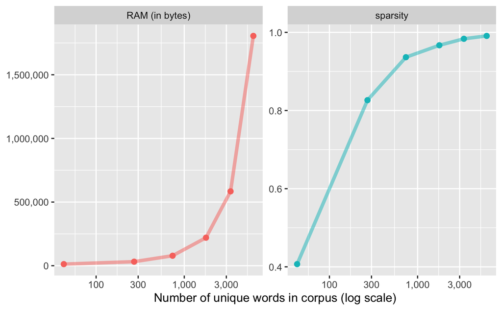

```r
get_dfm <- function(frac) {
  complaints %>%
    sample_frac(frac) %>%
    unnest_tokens(word, consumer_complaint_narrative) %>%
    anti_join(get_stopwords(), by = "word") %>%
    mutate(stem = wordStem(word)) %>%
    count(complaint_id, stem) %>%
    cast_dfm(complaint_id, stem, n)
}

set.seed(123)
tibble(frac = 2 ^ seq(-16, -6, 2)) %>%
  mutate(dfm = map(frac, get_dfm),
         words = map_dbl(dfm, quanteda::nfeat),
         sparsity = map_dbl(dfm, quanteda::sparsity),
         `RAM (in bytes)` = map_dbl(dfm, lobstr::obj_size)) %>%
  pivot_longer(sparsity:`RAM (in bytes)`, names_to = "measure") %>%
  ggplot(aes(words, value, color = measure)) +
  geom_line(size = 1.5, alpha = 0.5) +
  geom_point(size = 2) +
  facet_wrap(~measure, scales = "free_y") +
  scale_x_log10(labels = scales::label_comma()) +
  scale_y_continuous(labels = scales::label_comma()) +
  theme(legend.position = "none") +
  labs(x = "Number of unique words in corpus (log scale)",
       y = NULL)
```

## Creating Our Own Word Embeddings

- You can get word embeddings off the shelf (e.g. Glove)
- Or you can make them yourself
- Making them yourself, as we will see, can be very resource intensive (in terms of processing power, memory, and time)
- Also, don’t always have the option to create our own if we don’t have enough data (rule of thumb would be that you need more than a million words)
- First, we filter out words that are used only rarely in this data set and create a nested dataframe, with one row per complaint.

```r
tidy_complaints <- complaints %>%
  select(complaint_id, consumer_complaint_narrative) %>%
  unnest_tokens(word, consumer_complaint_narrative) %>%
  add_count(word) %>%
  filter(n >= 50) %>%
  select(-n)

nested_words <- tidy_complaints %>%
  nest(words = c(word))

nested_words
```

| complaint_id | words |
| --- | --- |
| 3384392 |  |
| 3417821 |  |
| 3433198 |  |
| 3366475 |  |
| 3385399 |  |
| 3444592 |  |
| 3379924 |  |
| 3446975 |  |
| 3214857 |  |
| 3417374 |  |

[output cut: 990 more lines]

- Next, we create a `slide_windows()` function, using the `slide()` function from the **slider** package that implements fast sliding window computations written in C.
- Our new function identifies skipgram windows in order to calculate the skipgram probabilities, how often we find each word near each other word.
- We do this by defining a fixed-size moving window that centers around each word.
- One of the arguments to this function is the `window_size`, which determines the size of the sliding window that moves through the text.
- The best choice for this window size depends on your analytical question
- A smaller window size, like three or four, focuses on how the word is used and learns what other words are functionally similar
- A larger window size, like 10, captures more information about the domain or topic of each word, not constrained by how functionally similar the words are
- A smaller window size is also faster to compute

```r
slide_windows <- function(tbl, window_size) {
  skipgrams <- slider::slide(
    tbl,
    ~.x,
    .after = window_size - 1,
    .step = 1,
    .complete = TRUE
  )

  safe_mutate <- safely(mutate)

  out <- map2(skipgrams,
              1:length(skipgrams),
              ~ safe_mutate(.x, window_id = .y))

  out %>%
    transpose() %>%
    pluck("result") %>%
    compact() %>%
    bind_rows()
}
```

- We can now calculate how often words occur on their own, and how often words occur together with other words.
- We do this using the point-wise mutual information index (PMI)
- It’s the logarithm of the probability of finding two words together, normalized for the probability of finding each of the words alone. We use PMI to measure which words occur together more often than expected based on how often they occurred on their own.
- For this example, let’s use a window size of *four*.
- This next step is the computationally expensive part of finding word embeddings with this method
- We can use the **furrr** package to take advantage of parallel processing because identifying skipgram windows in one document is independent from all the other documents.
- The following code chunk took two hours to run over the weekend on my fast laptop using parallel processing. So I saved the out put and load it in now…

```r
library(widyr)
library(furrr)

plan(multisession)  ## for parallel processing

tidy_pmi <- nested_words %>%
  mutate(words = future_map(words, slide_windows, 4L)) %>%
  unnest(words) %>%
  unite(window_id, complaint_id, window_id) %>%
  pairwise_pmi(word, window_id)

tidy_pmi
```

```r
library(widyr)
tidy_pmi <- read_csv("/Users/noeljohnson_laptop/Dropbox/Teaching/TaD_Sp2023/lectures/week_10_slides/tidy_pmi.csv")
tidy_pmi
```

| item1 | item2 | pmi |
| --- | --- | --- |
| systems | transworld | 7.091901799 |
| inc | transworld | 5.960560317 |
| is | transworld | -0.135084241 |
| trying | transworld | -0.107386491 |
| to | transworld | -0.002063973 |
| collect | transworld | 1.073085398 |
| a | transworld | -0.516189839 |
| debt | transworld | 0.919497642 |
| that | transworld | -0.541673223 |
| not | transworld | -1.171565683 |

[output cut: 990 more lines]

- When PMI is high, the two words are associated with each other, i.e., likely to occur together. When PMI is low, the two words are not associated with each other, unlikely to occur together.
- The step above used `unite()`, a function from **tidyr** that pastes multiple columns into one, to make a new column for `window_id` from the old `window_id` plus the `complaint_id`. This new column tells us which combination of window and complaint each word belongs to.
- We can next determine the word vectors from the PMI values using singular value decomposition (SVD).
- Is a method for dimensionality reduction via matrix factorization that works by taking our data and decomposing it onto special orthogonal axes. We covered this when we discussed PCA a couple weeks ago.
- We will use SVD to factor the PMI matrix into a set of smaller matrices containing the word embeddings with a size we get to choose (typically chosen to be in the low hundreds)
- Thus we get a matrix of dimension (`n_vocabulary * n_dim`) instead of dimension (`n_vocabulary * n_vocabulary`), which can be a vast reduction in size for large vocabularies.
- We use the `widely_svd()` function in **widyr** package, creating 100-dimensional word embeddings.

```r
tidy_word_vectors <- tidy_pmi %>%
  widely_svd(
    item1, item2, pmi,
    nv = 100, maxit = 1000
  )

tidy_word_vectors
```

| item1 | dimension | value |
| --- | --- | --- |
| systems | 1 | 1.646111e-02 |
| inc | 1 | 1.909679e-02 |
| is | 1 | 2.021640e-02 |
| trying | 1 | 4.227365e-02 |
| to | 1 | 9.039545e-03 |
| collect | 1 | 3.703085e-02 |
| a | 1 | 1.262743e-02 |
| debt | 1 | 4.300850e-02 |
| that | 1 | 1.358571e-02 |
| not | 1 | 2.132580e-02 |

[output cut: 990 more lines]